# Exercise 3

Adapted and excerpted from

Miranda D. Redmond, Daniel L. Preston, and Rowan M. Gaffney. 2014. Effects of multiple invasive species in experimental aquatic communities. Teaching Issues and Experiments in Ecology, Vol. 10: Practice #2. http://tiee.esa.org/vol/v10/issues/datasets/redmond/abstract.html

Preston DL, Henderson JS, Johnson PT. 2012. Community ecology of invasions: direct and indirect effects of multiple invasive species on aquatic communities. Ecology 93:1254-1261.

## Background

Invasive species can alter the ecology and evolution of native species and are important drivers of extinction (Vitousek et al. 1997, Clavero and Garcia-Berthou 2005). Yet, when species introductions occur alongside other types of environmental change, it can be challenging to disentangle the ecological impacts of individual nonnative species relative to other stressors (Didham et al. 2005, Light and Marchetti 2007). This challenge becomes amplified when multiple nonnative species co-occur. Understanding the individual and combined effects of multiple invasive species is especially important to natural resource managers, who are often pressed to prioritize which invasive species to manage (Simberloff et al. 2005).

Two common invaders in freshwater habitats in western North America are the mosquitofish (*Gambusia affinis* and *G. holbrooki*) and the American bullfrog (*Lithobates catesbeianus* or *Rana catesbeiana*). Both species are native to the eastern United States. Mosquitofish are the most widespread freshwater fish and have been introduced on every continent besides Antarctica, while bullfrogs are invasive throughout western North America and regions of South America, Europe, and Asia (Lever 2003, Pyke 2008). Both species have deleterious effects on native aquatic communities; mosquitofish prey on a wide diversity of aquatic invertebrates, amphibians, and other fish (Goodsell and Kats 1999, Leyse et al. 2004), and bullfrogs have negative effects on other aquatic amphibians through competition, predation, and disease transmission (Kiesecker et al. 2001, Pearl et al. 2004).

In this activity, you will use data from an outdoor mesocosm experiment to explore how these two common invasive species, mosquitofish and the American bullfrog, influence the native amphibian community and other aquatic taxa (snails, zooplankton, and phytoplankton). Bullfrog larvae are herbivores and mosquitofish prey on treefrogs, newts, and zooplankton. You will examine both the direct and indirect effects of two invasive species on native amphibians.

[figure not shown]

## Research Questions

1. How does the presence of bullfrogs and mosquitofish influence the survival of native amphibian species?
2. How does the presence of bullfrogs and mosquitofish influence the mass (an indicator of amphibian growth) of the native amphibians that survived?
3. How does the presence of bullfrogs and mosquitofish influence the density of snails, zooplankton (*Daphnia* and copepods), and phytoplankton (i.e. relative phytoplankton fluorescence)?

**What are the null hypotheses?**

## Data

A total of 20 outdoor pond mesocosms were established by placing 370 L of well water, 45 ml of pond mud, 15 g of rabbit chow, 25 g of dry leaf litter, and 1.25 L of pond water containing concentrated zooplankton into each plastic tank (1.3 m Length × 0.79 m Width × 0.64 m Height).

[figure not shown]

Mesocosms are small-scale representations of larger systems, which make it possible to do controlled experiments in a semi-realistic setting. The experiment involved a 2 x 2 factorial design (4 total treatments) that manipulated the presence of mosquitofish and bullfrogs within outdoor mesocosms.

[figure not shown]

The pond mud was added to introduce algae cells, the rabbit chow provided a source of nutrients to fuel growth of primary producers, and the dry leaf litter served as a source of cover for the amphibians. In each mesocosm, 10 native snails (*Helisoma sp.*), 15 native Pacific tree frog (*Pseudacris regilla*) tadpoles, 15 native western toad (*Bufo boreas*) tadpoles and 10 native California newts (*Taricha torosa*) were added. Five of the mesocosms only had the three native amphibian species (Native treatment). For the other 15 mesocosms, five of the mesocosms had 3 invasive American bullfrog tadpoles added in addition to the native species (Bullfrog treatment), five of the mesocosms had 5 invasive mosquitofish added in addition to native species (Mosquitofish treatment), and 5 of the mesocosms had 3 invasive American bullfrog tadpoles and 5 mosquitofish added in addition to the native species (Bullfrog + Mosquitofish treatment).

### Spreadsheet information

1. Species codes (used on many of the spreadsheets):  
   ‐ PSRE = Pacific Tree Frog (*Pseudacris regilla*)  
   ‐ BUBO = western Toad (*Bufo boreas*)  
   ‐ TATO = California newt (*Taricha torosa*)
2. Number of Zooplankton: Number in a sample of 6.9 L of water for the mesocosm.
3. Run Number (phytoplankton): Each sample was run five times. Use the mean of the five runs as the value for that mesocosm.
4. Phytoplankton Fluorescence = A relative value that measures the amount of light absorbed by chlorophyll in the sample. These numbers do not have units because they are relative to a sample blank, rather than absolute measurements.

## Exercise

Note that code is not provided for commands that have been provided previously. Refer to prior exercises if necessary.

### Load package `tidyverse`

```r
library(tidyverse)
```

### Load data and view it

The data can be found at the following paths relative to your home folder:  
“../shared/treatments.csv”  
“../shared/Amphib_survival.csv”  
“../shared/Amphib_mass.csv”  
“../shared/phytoplankton.csv”  
“../shared/snails_zoopl.csv”

```r
treatments <- read.csv("treatments.csv")
amphib_survival <- read.csv("Amphib_survival.csv")
amphib_mass <- read.csv("Amphib_mass.csv")
snails_and_zoopl <- read.csv("snails_zoopl.csv")
phytoplankton <- read.csv("phytoplankton.csv")
```

### How does the presence of bullfrogs and mosquitofish influence the survival of native amphibian species?

**Stop and think: what is missing from the survival data frame to answer this question?**

To put two data frames together based on a shared variable use the `left_join` function. This function takes two data frames and adds information from the right frame into the left frame while retaining the entire left frame.

```r
amphib_survival2 <- left_join(amphib_survival,treatments)
```

Now create a plot to examine the question.

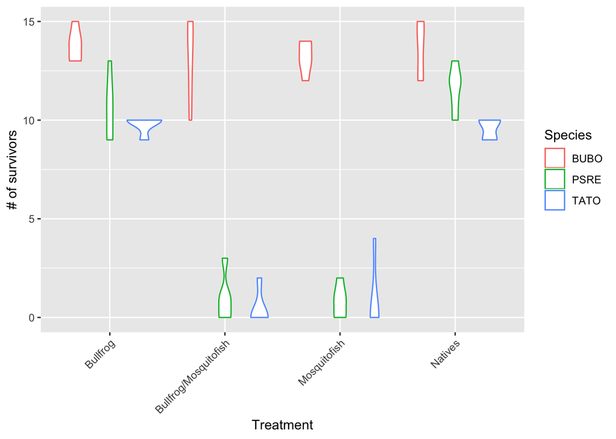

```r
ggplot(amphib_survival2, aes(Treatment,No_of_Survivors, color=Species))+
  geom_violin()+
  theme(axis.text.x=element_text(angle = 45, hjust = 1))+
  ylab("# of survivors")
```

```r
#mosquitofish strongly reduced treefrog and newt survival
#toads are highly toxic and distasteful as larvae
```

To compare the means of more than two groups (i.e. the three treatments here compared to the control) we use an ANOVA. Note that we use the simplest form of ANOVA here (1-way) even though this a factorial design (i.e. two interacting factors: bullfrogs, mosquitofish, and both). This approach is not correct but used here for simplicity. Additionally, survivors of all species are treated equally even though we observe in the graph that the treatment effect varied with species.

1. Construct the linear model relating the number of survivors to the treatment.
2. Output the ANOVA table.
3. Output the R^2 value from the summary of the linear model. R^2 indicates the fraction of variation in the response variable “explained” by treatment.

```r
survivalAnova <- lm(No_of_Survivors ~ Treatment, data = amphib_survival2)
anova(survivalAnova)
```

```
## Analysis of Variance Table
##
## Response: No_of_Survivors
##           Df  Sum Sq Mean Sq F value    Pr(>F)
## Treatment  3  653.73 217.911  10.204 1.845e-05 ***
## Residuals 56 1195.87  21.355
## ---
## Signif. codes:  0 '***' 0.001 '**' 0.01 '*' 0.05 '.' 0.1 ' ' 1
```

```r
survivalAnovaSummary <- summary(survivalAnova)
survivalAnovaSummary$r.squared
```

```
## [1] 0.3534458
```

### How does the presence of bullfrogs and mosquitofish influence the mass (an indicator of amphibian growth) of the native amphibians that survived?

Multiple measurements within a mesocosm (e.g. amphibian mass) are not independent of one another.  
Calculate the mean value per mesocosm and use this as the response variable. Hint: you’ll need to make a new table.

```r
amphib_mean_mass <- group_by(amphib_mass, Tank, Species) %>% summarise(mean_mass = mean(Mass))
```

Add the treatment information to the new table.

```r
amphib_mean_mass2 <- left_join(amphib_mean_mass,treatments)
```

Answer the question using a plot and ANOVA.

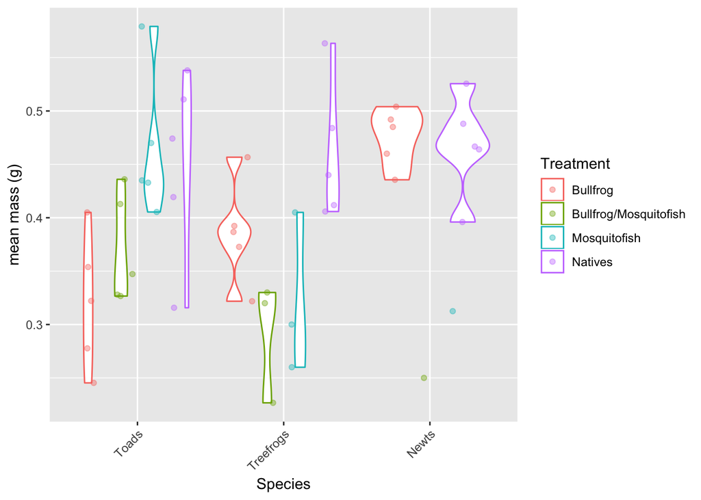

```r
ggplot(amphib_mean_mass2, aes(Species,mean_mass,color=Treatment )) +
  geom_violin()+ geom_point(alpha=.4,position=position_jitterdodge())+
  theme(axis.text.x=element_text(angle = 45, hjust = 1))+ylab("mean mass (g)")+
  scale_x_discrete(labels=c("Toads", "Treefrogs", "Newts"))
```

```r
#BUBO
#Toads compete with bullfrogs for resources (algae), so the presence of bullfrogs reduced their growth rates.
#mosquitofish slightly increased toad growth rates because mosquitofish preyed on treefrogs, thereby reducing competition between treefrogs and toads
#PSRE
#Treefrogs compete with bullfrogs for algae, but they are also preyed upon heavily by mosquitofish (have to hide; reduce foraging)
#TATO
#newts are carnivores so they do not compete with the bullfrogs
#newts that survive with mosquitofish were smaller because they also had to spend less time foraging to avoid predation

massAnova <- lm(mean_mass ~ Treatment, data = amphib_mean_mass2)
anova(massAnova)
```

```
## Analysis of Variance Table
##
## Response: mean_mass
##           Df  Sum Sq  Mean Sq F value   Pr(>F)
## Treatment  3 0.09722 0.032407  5.5283 0.002611 **
## Residuals 44 0.25793 0.005862
## ---
## Signif. codes:  0 '***' 0.001 '**' 0.01 '*' 0.05 '.' 0.1 ' ' 1
```

```r
massAnovaSummary <- summary(massAnova)
massAnovaSummary$r.squared
```

```
## [1] 0.2737448
```

### How does the presence of bullfrogs and mosquitofish influence the density of zooplankton (Daphnia and copepods)?

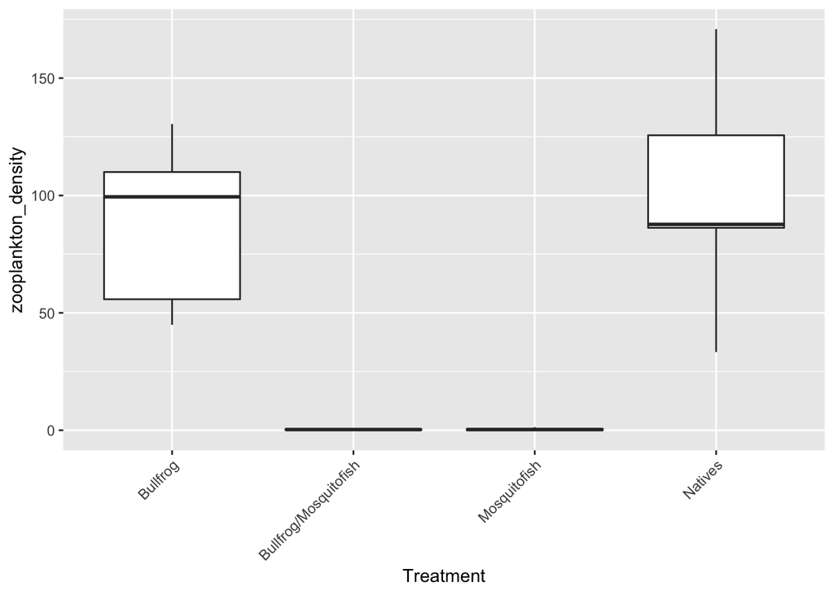

```r
zoopl <- snails_and_zoopl %>% filter(Species != "Snails") %>% group_by(Tank) %>%
  summarize(zooplankton = sum(No_of_Individuals))
zoopl2 <- left_join(zoopl,treatments)
zoopl2$zooplankton_density <- zoopl2$zooplankton / 6.9
ggplot(zoopl2, aes(Treatment,zooplankton_density)) +
  geom_boxplot()+
  theme(axis.text.x=element_text(angle = 45, hjust = 1))
```

### How does the presence of bullfrogs and mosquitofish influence the density of phytoplankton (i.e. relative phytoplankton fluorescence)?

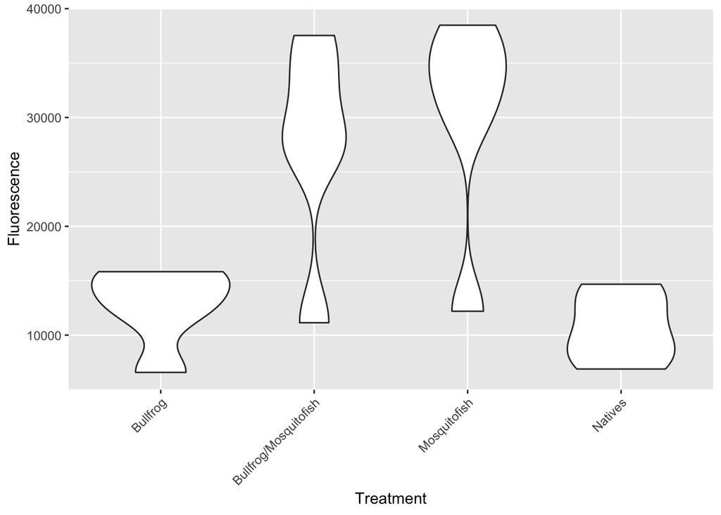

```r
phytoplankton2 <- group_by(phytoplankton, Tank) %>%
  summarise(Fluorescence = mean(Phytoplankton_Fluorescence))
phytoplankton3 <- left_join(phytoplankton2,treatments)
ggplot(phytoplankton3, aes(Treatment,Fluorescence)) +
  geom_violin()+
  theme(axis.text.x=element_text(angle = 45, hjust = 1))
```

```r
#grazing by zooplankton controlled the abundance of phytoplankton in the mesocosms
#mosquitofish impact zooplankton
```

### How does the presence of bullfrogs and mosquitofish influence the density of snails?

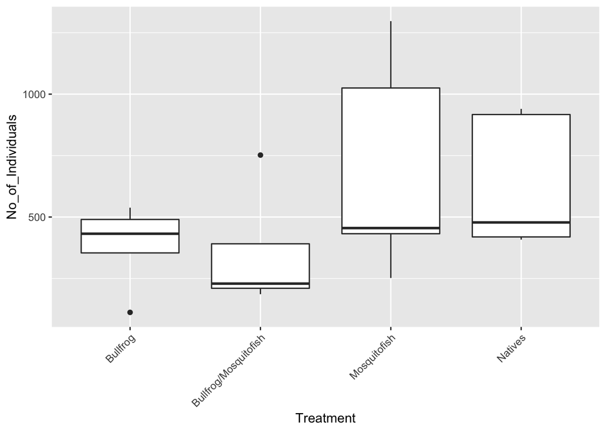

```r
snails <- snails_and_zoopl %>% filter(Species == "Snails")
snails2 <- left_join(snails,treatments)
ggplot(snails2, aes(Treatment,No_of_Individuals)) +
  geom_boxplot()+
  theme(axis.text.x=element_text(angle = 45, hjust = 1))
```

```r
#change in snail density is likely due to competition from bullfrogs.
#Snails had less to eat in the presence of bullfrogs and therefore produced fewer offspring.
```

### Redraw the food web to show bullfrogs and mosquitofish, and their direct and indirect effects.